# 📊 Customer Churn Intelligence using XGBoost & SHAP

Customer churn is one of the most critical challenges faced by subscription-based businesses. Acquiring new customers is significantly more expensive than retaining existing ones, making churn prediction a high-impact business problem.

In this notebook, we build an end-to-end machine learning pipeline to:

✅ Analyze customer behavior patterns

✅ Identify factors driving customer churn

✅ Build predictive churn models

✅ Explain predictions using SHAP Explainability

✅ Estimate Revenue at Risk

✅ Generate actionable business insights

By combining predictive analytics with explainable AI, this project demonstrates how machine learning can support strategic customer retention initiatives.

# 1️⃣ INTRODUCTION

# 2️⃣ IMPORT LIBRARIES

```python
import warnings
warnings.filterwarnings('ignore')

import numpy as np
import pandas as pd

import matplotlib.pyplot as plt
import seaborn as sns

from sklearn.preprocessing import LabelEncoder
from sklearn.model_selection import train_test_split

from sklearn.metrics import (
    accuracy_score,
    classification_report,
    confusion_matrix,
    roc_auc_score,
    roc_curve
)

from sklearn.linear_model import LogisticRegression
from sklearn.ensemble import RandomForestClassifier

from xgboost import XGBClassifier

import shap
```

# 3️⃣ LOAD DATA

```python
df = pd.read_csv('WA_Fn-UseC_-Telco-Customer-Churn.csv')
df.head()
```

|  | customerID | gender | SeniorCitizen | Partner | Dependents | tenure | PhoneService | MultipleLines | InternetService | OnlineSecurity | ... | DeviceProtection | TechSupport | StreamingTV | StreamingMovies | Contract | PaperlessBilling | PaymentMethod | MonthlyCharges | TotalCharges | Churn |
| --- | --- | --- | --- | --- | --- | --- | --- | --- | --- | --- | --- | --- | --- | --- | --- | --- | --- | --- | --- | --- | --- |
| 0 | 7590-VHVEG | Female | 0 | Yes | No | 1 | No | No phone service | DSL | No | ... | No | No | No | No | Month-to-month | Yes | Electronic check | 29.85 | 29.85 | No |
| 1 | 5575-GNVDE | Male | 0 | No | No | 34 | Yes | No | DSL | Yes | ... | Yes | No | No | No | One year | No | Mailed check | 56.95 | 1889.5 | No |
| 2 | 3668-QPYBK | Male | 0 | No | No | 2 | Yes | No | DSL | Yes | ... | No | No | No | No | Month-to-month | Yes | Mailed check | 53.85 | 108.15 | Yes |
| 3 | 7795-CFOCW | Male | 0 | No | No | 45 | No | No phone service | DSL | Yes | ... | Yes | Yes | No | No | One year | No | Bank transfer (automatic) | 42.30 | 1840.75 | No |
| 4 | 9237-HQITU | Female | 0 | No | No | 2 | Yes | No | Fiber optic | No | ... | No | No | No | No | Month-to-month | Yes | Electronic check | 70.70 | 151.65 | Yes |

5 rows × 21 columns

# 4️⃣ DATA QUALITY CHECK

```python
print("Shape:", df.shape)

df.info()

df.isnull().sum()
```

```
Shape: (7043, 21)
<class 'pandas.core.frame.DataFrame'>
RangeIndex: 7043 entries, 0 to 7042
Data columns (total 21 columns):
 #   Column            Non-Null Count  Dtype
---  ------            --------------  -----
 0   customerID        7043 non-null   object
 1   gender            7043 non-null   object
 2   SeniorCitizen     7043 non-null   int64
 3   Partner           7043 non-null   object
 4   Dependents        7043 non-null   object
 5   tenure            7043 non-null   int64
 6   PhoneService      7043 non-null   object
 7   MultipleLines     7043 non-null   object
 8   InternetService   7043 non-null   object
 9   OnlineSecurity    7043 non-null   object
 10  OnlineBackup      7043 non-null   object
 11  DeviceProtection  7043 non-null   object
 12  TechSupport       7043 non-null   object
 13  StreamingTV       7043 non-null   object
 14  StreamingMovies   7043 non-null   object
 15  Contract          7043 non-null   object
 16  PaperlessBilling  7043 non-null   object
 17  PaymentMethod     7043 non-null   object
 18  MonthlyCharges    7043 non-null   float64
 19  TotalCharges      7043 non-null   object
 20  Churn             7043 non-null   object
dtypes: float64(1), int64(2), object(18)
memory usage: 1.1+ MB
```

```
customerID          0
gender              0
SeniorCitizen       0
Partner             0
Dependents          0
tenure              0
PhoneService        0
MultipleLines       0
InternetService     0
OnlineSecurity      0
OnlineBackup        0
DeviceProtection    0
TechSupport         0
StreamingTV         0
StreamingMovies     0
Contract            0
PaperlessBilling    0
PaymentMethod       0
MonthlyCharges      0
TotalCharges        0
Churn               0
dtype: int64
```

```python
df.duplicated().sum()
```

```
np.int64(0)
```

```python
df.describe().T
```

|  | count | mean | std | min | 25% | 50% | 75% | max |
| --- | --- | --- | --- | --- | --- | --- | --- | --- |
| SeniorCitizen | 7043.0 | 0.162147 | 0.368612 | 0.00 | 0.0 | 0.00 | 0.00 | 1.00 |
| tenure | 7043.0 | 32.371149 | 24.559481 | 0.00 | 9.0 | 29.00 | 55.00 | 72.00 |
| MonthlyCharges | 7043.0 | 64.761692 | 30.090047 | 18.25 | 35.5 | 70.35 | 89.85 | 118.75 |

## Fix TotalCharges

```python
df['TotalCharges'] = pd.to_numeric(df['TotalCharges'], errors='coerce')
df['TotalCharges'].fillna(df['TotalCharges'].median(), inplace=True)
```

# 5️⃣ EDA SECTION

## Churn Distribution

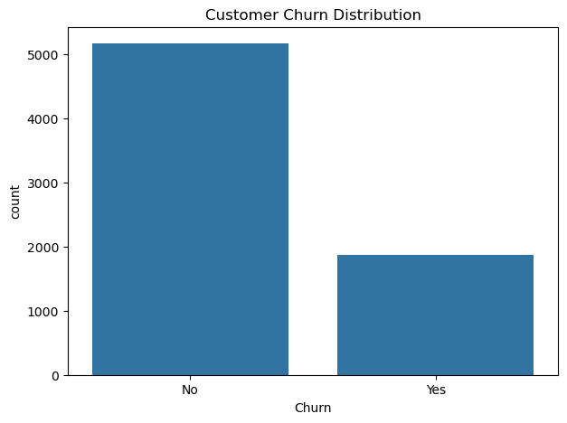

```python
plt.figure(figsize=(7,5))

sns.countplot(
    x='Churn',
    data=df
)

plt.title("Customer Churn Distribution")
plt.show()
```

## Contract Type

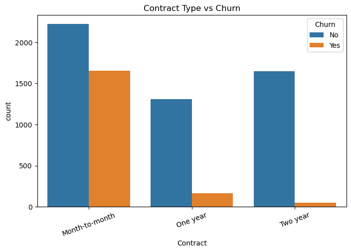

```python
plt.figure(figsize=(8,5))

sns.countplot(
    x='Contract',
    hue='Churn',
    data=df
)

plt.title("Contract Type vs Churn")
plt.xticks(rotation=20)
plt.show()
```

## Monthly Charges Distribution

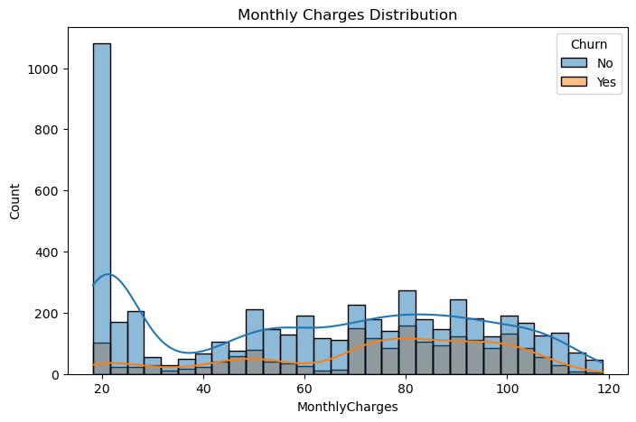

```python
plt.figure(figsize=(8,5))

sns.histplot(
    data=df,
    x='MonthlyCharges',
    hue='Churn',
    kde=True,
    bins=30
)

plt.title("Monthly Charges Distribution")
plt.show()
```

## Tenure vs Churn

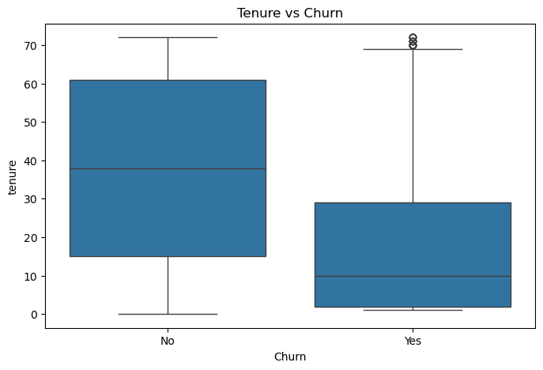

```python
plt.figure(figsize=(8,5))

sns.boxplot(
    x='Churn',
    y='tenure',
    data=df
)

plt.title("Tenure vs Churn")
plt.show()
```

## Payment Method Analysis

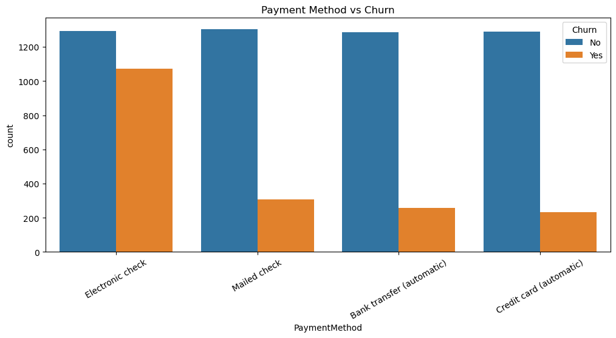

```python
plt.figure(figsize=(12,5))

sns.countplot(
    x='PaymentMethod',
    hue='Churn',
    data=df
)

plt.xticks(rotation=30)
plt.title("Payment Method vs Churn")
plt.show()
```

## Internet Service Analysis

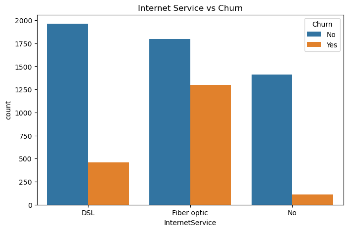

```python
plt.figure(figsize=(8,5))

sns.countplot(
    x='InternetService',
    hue='Churn',
    data=df
)

plt.title("Internet Service vs Churn")
plt.show()
```

## Churn Heatmap

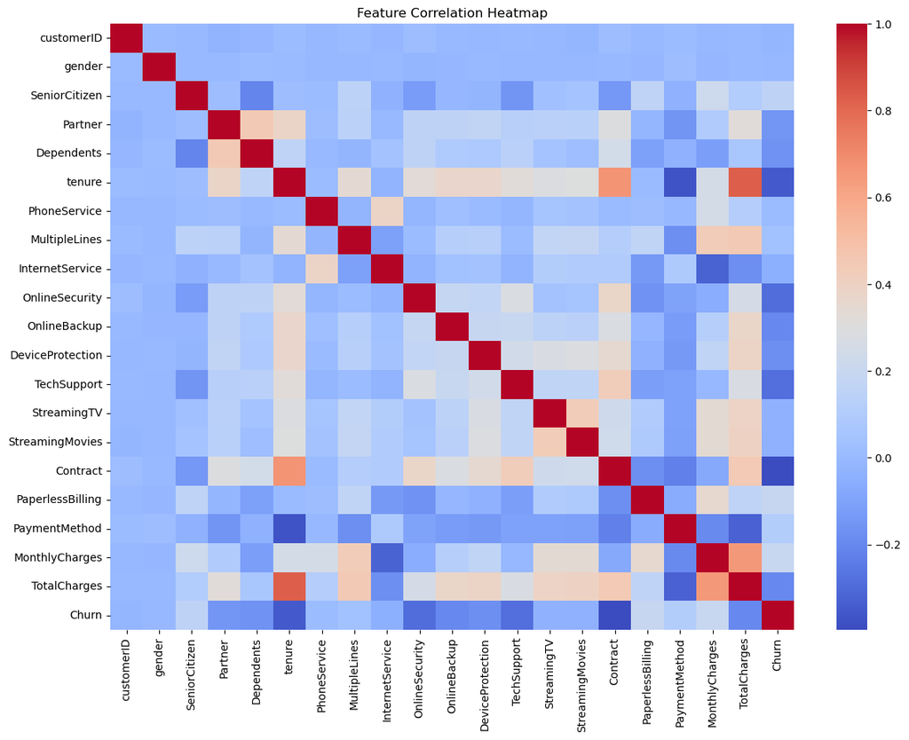

```python
temp = df.copy()

for col in temp.select_dtypes('object').columns:
    temp[col] = LabelEncoder().fit_transform(temp[col])

plt.figure(figsize=(14,10))
sns.heatmap(
    temp.corr(),
    cmap='coolwarm'
)

plt.title("Feature Correlation Heatmap")
plt.show()
```

## Revenue Analysis

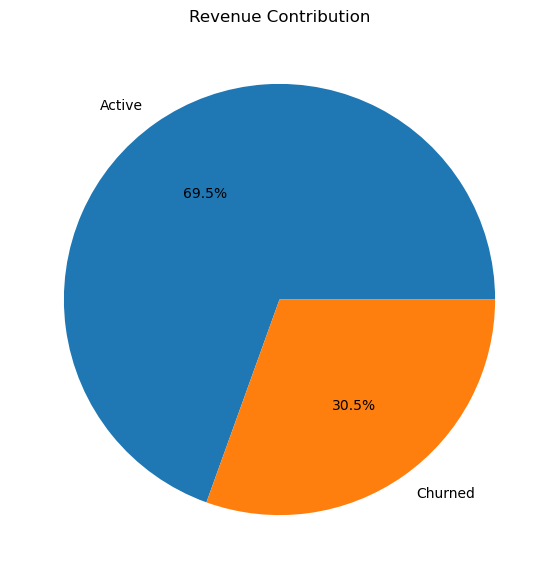

```python
churned_revenue = df[df['Churn']=='Yes']['MonthlyCharges'].sum()
active_revenue = df[df['Churn']=='No']['MonthlyCharges'].sum()
plt.figure(figsize=(7,7))

plt.pie(
    [active_revenue,churned_revenue],
    labels=['Active','Churned'],
    autopct='%1.1f%%'
)

plt.title("Revenue Contribution")
plt.show()
```

# 6️⃣ FEATURE ENGINEERING

## Customer Lifetime Value

```python
df['CLV'] = df['MonthlyCharges'] * df['tenure']
```

## Average Monthly Spend

```python
df['AvgMonthlySpend'] = (
    df['TotalCharges'] /
    (df['tenure'] + 1)
)
```

## Encode Target

```python
df['Churn'] = df['Churn'].map({
    'No':0,
    'Yes':1
})
```

## Label Encoding

```python
le = LabelEncoder()

for col in df.select_dtypes('object').columns:
    df[col] = le.fit_transform(df[col])
```

# 7️⃣ TRAIN TEST SPLIT

```python
X = df.drop('Churn', axis=1)
y = df['Churn']

X_train, X_test, y_train, y_test = train_test_split(
    X,
    y,
    test_size=0.2,
    random_state=42,
    stratify=y
)
```

# 8️⃣ MODEL TRAINING

## Logistic Regression

```python
lr = LogisticRegression(max_iter=1000)
lr.fit(X_train,y_train)
lr_pred = lr.predict(X_test)
print(classification_report(y_test,lr_pred))
```

```
              precision    recall  f1-score   support

           0       0.84      0.89      0.87      1035
           1       0.64      0.54      0.59       374

    accuracy                           0.80      1409
   macro avg       0.74      0.72      0.73      1409
weighted avg       0.79      0.80      0.79      1409
```

## Random Forest

```python
rf = RandomForestClassifier(
    n_estimators=300,
    random_state=42
)

rf.fit(X_train,y_train)
rf_pred = rf.predict(X_test)
print(classification_report(y_test,rf_pred))
```

```
              precision    recall  f1-score   support

           0       0.83      0.90      0.86      1035
           1       0.63      0.48      0.54       374

    accuracy                           0.79      1409
   macro avg       0.73      0.69      0.70      1409
weighted avg       0.77      0.79      0.78      1409
```

## XGBoost

```python
xgb = XGBClassifier(
    n_estimators=500,
    max_depth=6,
    learning_rate=0.05,
    subsample=0.8,
    colsample_bytree=0.8,
    random_state=42
)

xgb.fit(X_train,y_train)
xgb_pred = xgb.predict(X_test)
print(classification_report(y_test,xgb_pred))
```

```
              precision    recall  f1-score   support

           0       0.84      0.89      0.87      1035
           1       0.64      0.55      0.59       374

    accuracy                           0.80      1409
   macro avg       0.74      0.72      0.73      1409
weighted avg       0.79      0.80      0.79      1409
```

# 9️⃣ MODEL COMPARISON

```python
models = ['Logistic','Random Forest','XGBoost']

scores = [
    accuracy_score(y_test,lr_pred),
    accuracy_score(y_test,rf_pred),
    accuracy_score(y_test,xgb_pred)
]

comparison = pd.DataFrame({
    'Model':models,
    'Accuracy':scores
})

comparison
```

|  | Model | Accuracy |
| --- | --- | --- |
| 0 | Logistic | 0.798439 |
| 1 | Random Forest | 0.786373 |
| 2 | XGBoost | 0.797019 |

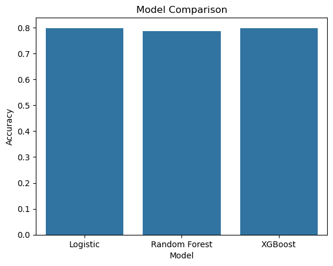

```python
sns.barplot(
    data=comparison,
    x='Model',
    y='Accuracy'
)

plt.title("Model Comparison")
plt.show()
```

# 🔟 CONFUSION MATRIX

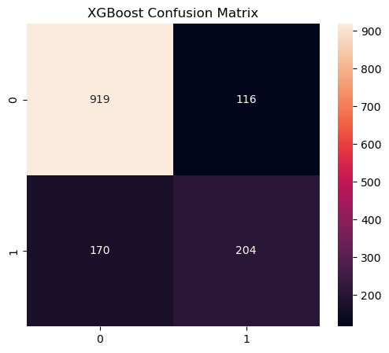

```python
cm = confusion_matrix(y_test,xgb_pred)
plt.figure(figsize=(6,5))

sns.heatmap(
    cm,
    annot=True,
    fmt='d'
)

plt.title("XGBoost Confusion Matrix")
plt.show()
```

# 1️⃣1️⃣ ROC CURVE

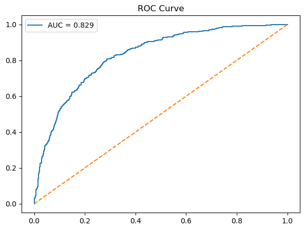

```python
probs = xgb.predict_proba(X_test)[:,1]
fpr,tpr,_ = roc_curve(y_test,probs)
auc = roc_auc_score(y_test,probs)
plt.figure(figsize=(7,5))

plt.plot(fpr,tpr,label=f'AUC = {auc:.3f}')
plt.plot([0,1],[0,1],'--')

plt.legend()

plt.title("ROC Curve")
plt.show()
```

# 1️⃣2️⃣ SHAP EXPLAINABILITY

```python
explainer = shap.TreeExplainer(xgb)
shap_values = explainer.shap_values(X_test)
```

## Global Importance

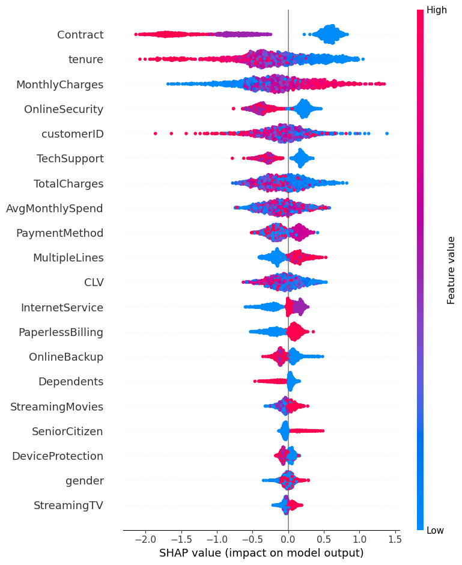

```python
shap.summary_plot(
    shap_values,
    X_test
)
```

## Bar Plot

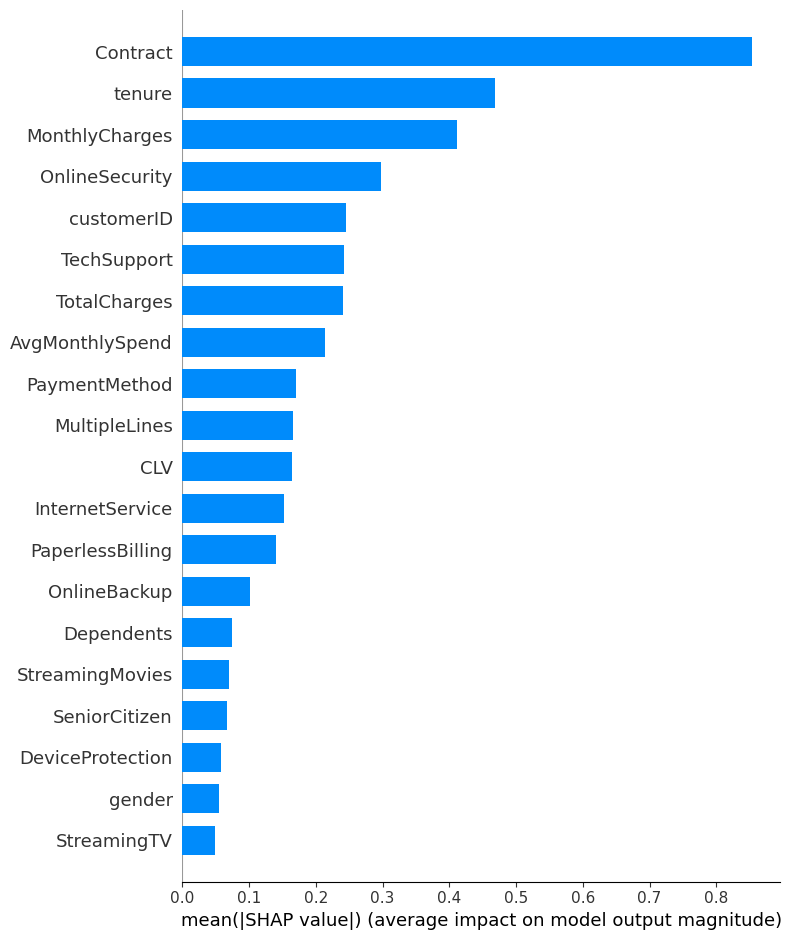

```python
shap.summary_plot(
    shap_values,
    X_test,
    plot_type='bar'
)
```

# 1️⃣3️⃣ REVENUE AT RISK ANALYSIS

```python
risk_df = X_test.copy()
risk_df['Actual'] = y_test.values
risk_df['ChurnProbability'] = probs

risk_df['RevenueRisk'] = (
    risk_df['MonthlyCharges']
    * risk_df['ChurnProbability']
)
```

```python
total_risk = risk_df['RevenueRisk'].sum()
print(f"Estimated Revenue At Risk: ${total_risk:,.2f}")
```

```
Estimated Revenue At Risk: $26,950.14
```

## Revenue Risk Distribution

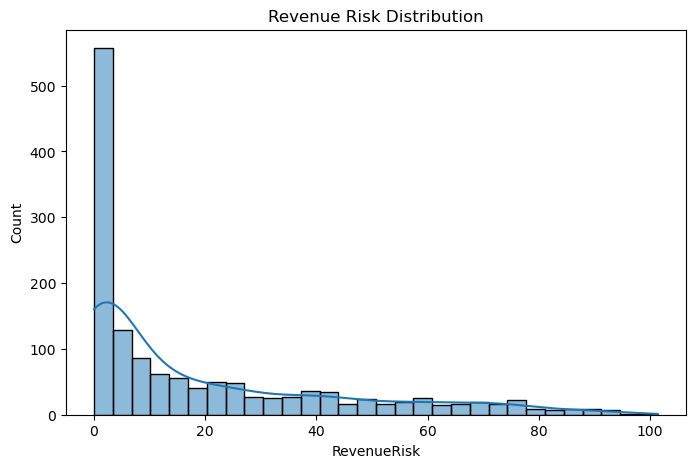

```python
plt.figure(figsize=(8,5))

sns.histplot(
    risk_df['RevenueRisk'],
    bins=30,
    kde=True
)

plt.title("Revenue Risk Distribution")
plt.show()
```

# 1️⃣4️⃣ CUSTOMER SEGMENTATION

```python
risk_df['RiskSegment'] = pd.cut(
    risk_df['ChurnProbability'],
    bins=[0, 0.3, 0.7, 1.0],
    labels=['Low Risk', 'Medium Risk', 'High Risk'],
    include_lowest=True
)

print(risk_df[['ChurnProbability', 'RiskSegment']].head())
```

```
      ChurnProbability  RiskSegment
437           0.002591     Low Risk
2280          0.953757    High Risk
2235          0.115391     Low Risk
4460          0.416458  Medium Risk
3761          0.001368     Low Risk
```

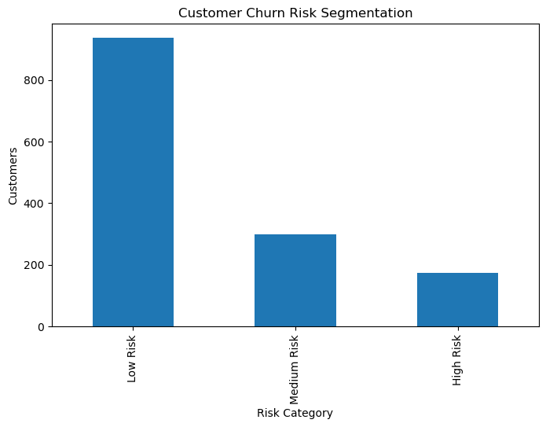

```python
segment_counts = risk_df['RiskSegment'].value_counts()

plt.figure(figsize=(8,5))

segment_counts.plot(kind='bar')

plt.title("Customer Churn Risk Segmentation")
plt.ylabel("Customers")
plt.xlabel("Risk Category")

plt.show()
```

# 1️⃣5️⃣ BUSINESS INSIGHTS

```python
top_risk = risk_df.sort_values(
    'RevenueRisk',
    ascending=False
)

top_risk.head(10)
```

|  | customerID | gender | SeniorCitizen | Partner | Dependents | tenure | PhoneService | MultipleLines | InternetService | OnlineSecurity | ... | PaperlessBilling | PaymentMethod | MonthlyCharges | TotalCharges | CLV | AvgMonthlySpend | Actual | ChurnProbability | RevenueRisk | RiskSegment |
| --- | --- | --- | --- | --- | --- | --- | --- | --- | --- | --- | --- | --- | --- | --- | --- | --- | --- | --- | --- | --- | --- |
| 1568 | 2301 | 1 | 1 | 0 | 0 | 11 | 1 | 2 | 1 | 0 | ... | 1 | 2 | 111.40 | 1183.05 | 1225.40 | 98.58750 | 0 | 0.910080 | 101.382934 | High Risk |
| 2280 | 1896 | 0 | 1 | 0 | 0 | 8 | 1 | 2 | 1 | 0 | ... | 1 | 1 | 100.15 | 908.55 | 801.20 | 100.95000 | 0 | 0.953757 | 95.518804 | High Risk |
| 6365 | 6280 | 1 | 1 | 1 | 0 | 7 | 1 | 2 | 1 | 0 | ... | 1 | 2 | 101.95 | 700.85 | 713.65 | 87.60625 | 1 | 0.924145 | 94.216551 | High Risk |
| 3727 | 6393 | 0 | 0 | 0 | 0 | 3 | 1 | 2 | 1 | 0 | ... | 1 | 2 | 96.60 | 291.90 | 289.80 | 72.97500 | 1 | 0.973509 | 94.041011 | High Risk |
| 85 | 3100 | 1 | 0 | 0 | 0 | 9 | 1 | 2 | 1 | 0 | ... | 1 | 1 | 99.30 | 918.75 | 893.70 | 91.87500 | 0 | 0.942185 | 93.558933 | High Risk |
| 2631 | 4871 | 1 | 1 | 1 | 0 | 7 | 1 | 2 | 1 | 0 | ... | 1 | 2 | 99.25 | 665.45 | 694.75 | 83.18125 | 1 | 0.941052 | 93.399377 | High Risk |
| 6866 | 180 | 1 | 0 | 0 | 0 | 1 | 1 | 2 | 1 | 0 | ... | 1 | 2 | 95.45 | 95.45 | 95.45 | 47.72500 | 1 | 0.975593 | 93.120395 | High Risk |
| 6894 | 967 | 1 | 1 | 1 | 0 | 3 | 1 | 2 | 1 | 0 | ... | 1 | 2 | 105.90 | 334.65 | 317.70 | 83.66250 | 1 | 0.871339 | 92.274809 | High Risk |
| 3380 | 3672 | 1 | 1 | 1 | 0 | 1 | 1 | 2 | 1 | 0 | ... | 1 | 2 | 95.10 | 95.10 | 95.10 | 47.55000 | 1 | 0.960583 | 91.351435 | High Risk |
| 2246 | 5109 | 0 | 0 | 1 | 1 | 1 | 1 | 2 | 1 | 2 | ... | 1 | 2 | 102.45 | 102.45 | 102.45 | 51.22500 | 1 | 0.886635 | 90.835787 | High Risk |

10 rows × 26 columns

# 1️⃣6️⃣ Conclusion

## Key Findings

✅ Customers on month-to-month contracts exhibited significantly higher churn rates.

✅ Short-tenure customers were more likely to leave.

✅ Higher monthly charges increased churn probability.

✅ Electronic check users demonstrated elevated churn risk.

✅ SHAP analysis identified tenure, contract type, and monthly charges as the strongest drivers of churn.

✅ Revenue-at-risk analytics highlighted high-value customers requiring immediate retention interventions.

## Business Recommendations

1. Introduce loyalty incentives for low-tenure customers.
2. Promote long-term contract adoption.
3. Offer targeted discounts to high-risk customers.
4. Monitor high monthly charge segments.
5. Build proactive churn intervention campaigns.